# 2019-01-16.within_vs_between_figure_final

```python
import pandas as pd
import numpy as np

import matplotlib.pyplot as plt
import seaborn as sns

import matplotlib as mpl
import matplotlib.cm as cm

%matplotlib inline
```

```python
fname = '../../data/analysis/within_vs_between_beta.txt'
df = pd.read_csv(fname, sep='\t')
df.head()
```

|  | subject | site | sample | site_comparison | n_btw_patient | n_lower | within_beta | mean_inter_beta | median_inter_beta | percent_lower |
| --- | --- | --- | --- | --- | --- | --- | --- | --- | --- | --- |
| 0 | 01-112-7 | throat_swab | 01-112-7TI | gastric_fluid-throat_swab | 51 | 51 | 0.993353 | 0.609156 | 0.611674 | 1.000000 |
| 1 | 01-112-7 | gastric_fluid | 01-112-7GI | gastric_fluid-throat_swab | 42 | 22 | 0.993353 | 0.976368 | 0.993309 | 0.523810 |
| 2 | 01-164-7 | throat_swab | 01-164-7TI | gastric_fluid-throat_swab | 51 | 0 | 0.091874 | 0.641798 | 0.634818 | 0.000000 |
| 3 | 01-164-7 | gastric_fluid | 01-164-7GI | gastric_fluid-throat_swab | 42 | 0 | 0.091874 | 0.719315 | 0.700759 | 0.000000 |
| 4 | 01-173-4 | gastric_fluid | 01-173-4G | gastric_fluid-throat_swab | 42 | 5 | 0.516810 | 0.637119 | 0.615343 | 0.119048 |

```python
df['inter_minus_intra'] = df['mean_inter_beta'] - df['within_beta']
```

```python
df.groupby(['site_comparison', 'site']).size()
```

```
site_comparison            site
bal-gastric_fluid          bal               89
                           gastric_fluid     89
bal-throat_swab            bal               73
                           throat_swab       73
gastric_fluid-throat_swab  gastric_fluid    112
                           throat_swab      112
dtype: int64
```

# Paired slope graph

In words, this plot shows the within-patient beta diversity (left points) across two different sites (each panel), as compared to the average across-patient beta diversity (right points) between each of the sites in the within-comparison (the two slope graphs on each panel).

In maybe better words, here's what we're showing:

- each panel is a different type of within-patient comparison
- each slope graph is a different type of across-patient comparison for a given within-patient comparison
- each point corresponds to a patient
- the left points are that patient's within-patient JSD
- the right points are the average JSD between that patient's site X and all other patients' site X
  - each panel has two site X's, one for each in the within-patient comparison

As a reminder, a lower y-value means that communities are more similar.

Upward sloping (red) lines indicate that the two different communities are *more similar* within that patient than the average of that patient's given site with all other patient's same site.

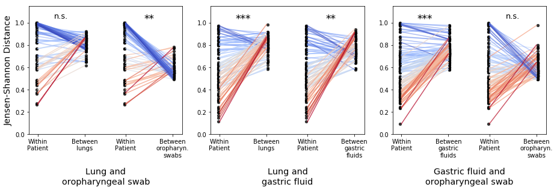

```python
site_lbl_dict = {
    'bal': 'lungs\n',
    'throat_swab': 'oropharyn.\nswabs',
    'gastric_fluid': 'gastric\nfluids'
}
site_comp_dict = {
    'bal-throat_swab': 'Lung and\noropharyngeal swab',
    'bal-gastric_fluid': 'Lung and\ngastric fluid',
    'gastric_fluid-throat_swab': 'Gastric fluid and\noropharyngeal swab'
}

pval_dict = {'bal-throat_swab/bal': 'n.s.',
             'bal-throat_swab/throat_swab': '**',
             'bal-gastric_fluid/bal': '***',
             'bal-gastric_fluid/gastric_fluid': '**',
             'gastric_fluid-throat_swab/gastric_fluid': '***',
             'gastric_fluid-throat_swab/throat_swab': 'n.s.'}

fig, ax = plt.subplots(1, 3, figsize=(13, 4.5))

i = 0
# Manually enocde these so the order matches the rest of paper
site_comparisons = ['bal-throat_swab', 'bal-gastric_fluid', 'gastric_fluid-throat_swab']

for site_comp in site_comparisons:
    subdf = df.query('site_comparison == @site_comp')
    xi = 0
    allxs = []
    all_xlabels = []
    for site, site_subdf in subdf.groupby('site'):
        # Sort the dataframe by absolute value of the difference, so that
        # the bigger differences are plotted last (i.e. top of the layers)
        site_subdf.loc[site_subdf.index, 'abs_inter_minus_intra'] = (
            site_subdf['inter_minus_intra'].abs())
        site_subdf = site_subdf.sort_values(by='abs_inter_minus_intra')

        # These are the two sets of y-values, paired
        beta_within = site_subdf['within_beta'].values
        beta_between = site_subdf['mean_inter_beta'].values

        # Set up color from the dataframe
        # Note: making this symmetric still looks super washed out
#        # Get maximum difference (absolute value)
#        max_diff = site_subdf['inter_minus_intra'].abs().max()
        vmax = site_subdf['inter_minus_intra'].max()
        vmin = site_subdf['inter_minus_intra'].min()

        # Make normalized colormap
        norm = mpl.colors.Normalize(vmin=vmin, vmax=vmax)
        #cmap = sns.diverging_palette(220,20,as_cmap=True)
        cmap = cm.get_cmap('coolwarm')
        m = cm.ScalarMappable(norm=norm, cmap=cmap)

        c = site_subdf['inter_minus_intra'].apply(m.to_rgba)

        # And set up alpha values for the lines
        # blue should be more transparent (lower alpha) bc it's visually darker
        alphas = [0.7 if j > 0  else 0.5 for j in site_subdf['inter_minus_intra'].values]

        # The 0.2 changes how far apart the dots are for one comparison
        slope_space = 0.2
        x1 = xi - slope_space
        x2 = xi + slope_space

        # Plot the lines connecting the dots
        for withini, betweeni, ci, ai in zip(beta_within, beta_between, c, alphas):
            ax[i].plot([x1, x2], [withini, betweeni], c=ci, alpha=ai)

        ax[i].scatter(len(beta_within)*[x1-0.01], beta_within,
            s=25, linewidths=0.25, edgecolor='k',
            c='k', alpha=0.8)
        ax[i].scatter(len(beta_between)*[x2+0.01], beta_between,
            s=25, linewidths=0.25, edgecolor='k',
            c='k', alpha=0.8)

        allxs += [x1, x2]
        all_xlabels += ['Within\nPatient\n\n',
                        'Between\n' + site_lbl_dict[site]]

        # Add pvalue asterisk
        x_pval = x1 + (x2 - x1)/2.0
        txt_pval = pval_dict[site_comp + '/' + site]
        if txt_pval == "n.s.":
            fs = 13
            y = 1.04
        else:
            fs = 17
            y = 1.008
        ax[i].text(x_pval, y, txt_pval,
                   fontsize=fs, ha='center')

        # This one changes how far apart each pair of points is in an aixs
        xi += 0.75

    ax[i].set_xticks(allxs)
    ax[i].set_xticklabels(all_xlabels)

    ax[i].set_xlabel(site_comp_dict[site_comp], fontsize='x-large')

    ax[i].set_ylim([0, 1.15])
    if i == 0:
        ax[i].set_ylabel('Jensen-Shannon Distance', fontsize='x-large')

    i += 1

fig.tight_layout()
fig.savefig('../../final/figures/figure.within_pt_vs_between_pt.png', dpi=200)
```

In the caption, I think I will directly explain how to interpret each panel.

Left panel: lung and oropharyngeal microbiomes within people are more different from each other than oropharyngeal microbiomes are across people. Middle panel: lung and stomach microbiomes are more similar within people than lungs and stomachs are across people. Right panel: oropharyngeal and stomach microbiomes within people are more similar than stomachs across people.

## P values

We'll do a paired wilcoxon. From [scipy.stats.wilcoxon](https://docs.scipy.org/doc/scipy/reference/generated/scipy.stats.wilcoxon.html):

```
The Wilcoxon signed-rank test tests the null hypothesis that two related paired samples come from the same distribution. In particular, it tests whether the distribution of the differences x - y is symmetric about zero. It is a non-parametric version of the paired T-test.
```

We'll also calculate the direction of the effect.

```python
from scipy.stats import wilcoxon
pval_res = []
for site_comp in site_comparisons:
    subdf = df.query('site_comparison == @site_comp')

    for site, site_subdf in subdf.groupby('site'):

        # These are the two sets of y-values, paired
        beta_within = site_subdf['within_beta'].values
        beta_between = site_subdf['mean_inter_beta'].values
        w, p = wilcoxon(beta_within, beta_between)

        if np.mean(beta_within) > np.mean(beta_between):
            lbl = 'within > between'
        else:
            lbl = 'within < between'

        pval_res.append([site_comp, site, p, lbl, w])
pval_df = pd.DataFrame(pval_res,
    columns=['within pt comparison', 'between pt site', 'p value', 'direction', 'test stat'])
pval_df
```

|  | within pt comparison | between pt site | p value | direction | test stat |
| --- | --- | --- | --- | --- | --- |
| 0 | bal-throat_swab | bal | 7.146729e-01 | within < between | 1284.0 |
| 1 | bal-throat_swab | throat_swab | 2.367202e-08 | within > between | 335.0 |
| 2 | bal-gastric_fluid | bal | 9.220407e-12 | within < between | 336.0 |
| 3 | bal-gastric_fluid | gastric_fluid | 6.875369e-08 | within < between | 684.0 |
| 4 | gastric_fluid-throat_swab | gastric_fluid | 5.003166e-15 | within < between | 468.0 |
| 5 | gastric_fluid-throat_swab | throat_swab | 1.845982e-01 | within < between | 2707.0 |

Lung and throat microbiomes within people:

- similarly different as lungs across people
- more different than throats across people

Lung and stomach microbiomes within people:

- more similar than lungs across people
- more similar than stomachs across people

Throat and stomach microbiomes within people:

- more similar than stomachs across people
- similarly different as throats across people

# Other plots

Useful stackoverflow post for the above plot, FYI: https://stackoverflow.com/questions/15140072/how-to-map-number-to-color-using-matplotlibs-colormap?rq=1

Same plot as above, but here the color scale is symmetric and defined according to the global maximum difference. Plots are very washed out.

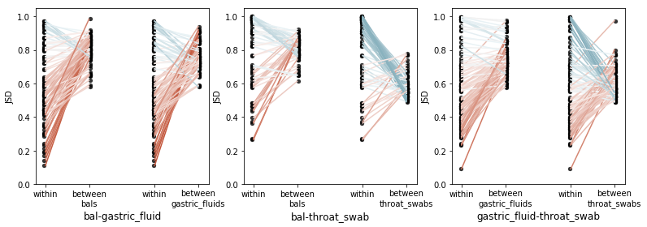

```python
# Get maximum difference (absolute value)
max_diff = df['inter_minus_intra'].abs().max()

# Make normalized colormap
# My understanding is that the "norm" sets the min and max of the data,
# and the cmap sets the range of colors
norm = mpl.colors.Normalize(vmin=-max_diff, vmax=max_diff)
cmap = sns.diverging_palette(220,20,as_cmap=True)
# So together they set a range of colors for the given data
m = cm.ScalarMappable(norm=norm, cmap=cmap)

# If we were just using cmap, you can call cmap(x) directly
# But to use the normalized color map, we call m.to_rgba()
df['c'] = df['inter_minus_intra'].apply(m.to_rgba)

# Now let's re-plot with these colors
fig, ax = plt.subplots(1, 3, figsize=(13, 4))

i = 0
for site_comp, subdf in df.groupby('site_comparison'):
    xi = 0
    allxs = []
    all_xlabels = []
    for site, site_subdf in subdf.groupby('site'):
        # These are the two sets of y-values, paired
        beta_within = site_subdf['within_beta'].values
        beta_between = site_subdf['mean_inter_beta'].values

        # Set up color from the dataframe
        c = site_subdf['c'].tolist()

#        # And set up alpha values for the lines (brown should be more transparent)
#        alphas = [0.8 if j == asp_colors[asp] else 0.6 for j in c]

        # The 0.2 changes how far apart the dots are for one comparison
        slope_space = 0.2
        x1 = xi - slope_space
        x2 = xi + slope_space

        # Plot the lines connecting the dots
        for withini, betweeni, ci in zip(beta_within, beta_between, c):
            ax[i].plot([x1, x2], [withini, betweeni], c=ci)

        ax[i].scatter(len(beta_within)*[x1-0.01], beta_within,
            s=25, linewidths=0.25, edgecolor='k',
            c='k', alpha=0.8)
        ax[i].scatter(len(beta_between)*[x2+0.01], beta_between,
            s=25, linewidths=0.25, edgecolor='k',
            c='k', alpha=0.8)

        allxs += [x1, x2]
        all_xlabels += ['within', 'between\n' + site + "s"]

        # This one changes how far apart each pair of points is in an aixs
        xi += 1

    ax[i].set_xticks(allxs)
    ax[i].set_xticklabels(all_xlabels)

    ax[i].set_xlabel(site_comp, fontsize='large')

    ax[i].set_ylabel('JSD')
    ax[i].set_ylim([0, 1.05])
    i += 1
```

Next, same as above but with even less complicated colors. (This was my first version of the plot)

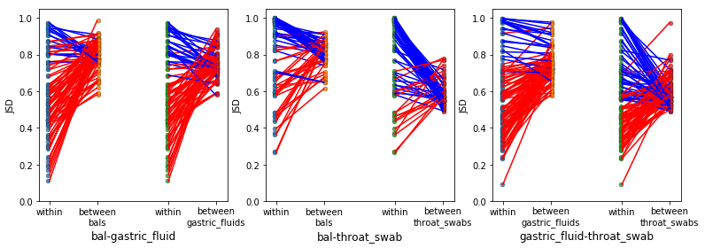

```python
fig, ax = plt.subplots(1, 3, figsize=(13, 4))

i = 0

for site_comp, subdf in df.groupby('site_comparison'):
#    sns.boxplot(data=subdf, x='site', y='inter_minus_intra', ax=ax[i], color='gray')
    xi = 0
    allxs = []
    all_xlabels = []
    for site, site_subdf in subdf.groupby('site'):
        # These are the two sets of y-values, paired
        beta_within = site_subdf['within_beta'].values
        beta_between = site_subdf['mean_inter_beta'].values

        # Set up color: blue for higher beta_within, brown for higher in normal
        c = (beta_within - beta_between) > 0
        c = ['blue' if j else 'red' for j in c]

#        # And set up alpha values for the lines (brown should be more transparent)
#        alphas = [0.8 if j == asp_colors[asp] else 0.6 for j in c]

        # The 0.2 changes how far apart the dots are for one comparison
        slope_space = 0.2
        x1 = xi - slope_space
        x2 = xi + slope_space

        # Plot the lines connecting the dots
        for withini, betweeni, ci in zip(beta_within, beta_between, c):
            ax[i].plot([x1, x2], [withini, betweeni], c=ci)

        ax[i].scatter(len(beta_within)*[x1-0.01], beta_within,
                   s=25, linewidths=0.25, edgecolor='k', alpha=0.8)
        ax[i].scatter(len(beta_between)*[x2+0.01], beta_between,
                   s=25, linewidths=0.25, edgecolor='k', alpha=0.8)

        allxs += [x1, x2]
        all_xlabels += ['within', 'between\n' + site + "s"]

        # This one changes how far apart each pair of points is in an aixs
        xi += 1

    ax[i].set_xticks(allxs)
    ax[i].set_xticklabels(all_xlabels)

    ax[i].set_xlabel(site_comp, fontsize='large')

    ax[i].set_ylabel('JSD')
    ax[i].set_ylim([0, 1.05])
    i += 1
```

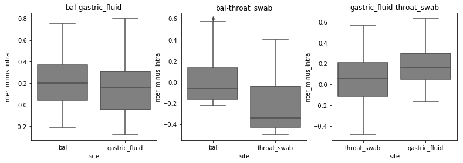

```python
fig, ax = plt.subplots(1, 3, figsize=(13, 4))

i = 0
for s, subdf in df.groupby('site_comparison'):
    sns.boxplot(data=subdf, x='site', y='inter_minus_intra', ax=ax[i], color='gray')
    ax[i].set_title(s)
    i += 1
```

For each plot, the values are the difference between that patient's mean similarity to all other patient's site and that patients' similarity with the other site.

So if it's above zero, that means that on average, the within-patient communities are more similar than the between-patient comparison.

If it's below zero, that means that the within-patient are more **different** than similarities in sites between patients.

```python
from scipy.stats import wilcoxon
for site, subdf in df.groupby(['site', 'site_comparison']):
    print(site[0], site[1], wilcoxon(subdf['inter_minus_intra']))
```

```
('bal', 'bal-gastric_fluid', WilcoxonResult(statistic=336.0, pvalue=9.22040698528812e-12))
('bal', 'bal-throat_swab', WilcoxonResult(statistic=1284.0, pvalue=0.7146729223004393))
('gastric_fluid', 'bal-gastric_fluid', WilcoxonResult(statistic=684.0, pvalue=6.87536895975907e-08))
('gastric_fluid', 'gastric_fluid-throat_swab', WilcoxonResult(statistic=468.0, pvalue=5.003166034881307e-15))
('throat_swab', 'bal-throat_swab', WilcoxonResult(statistic=335.0, pvalue=2.3672024097703973e-08))
('throat_swab', 'gastric_fluid-throat_swab', WilcoxonResult(statistic=2707.0, pvalue=0.18459823649360796))
```

# Other types of plots

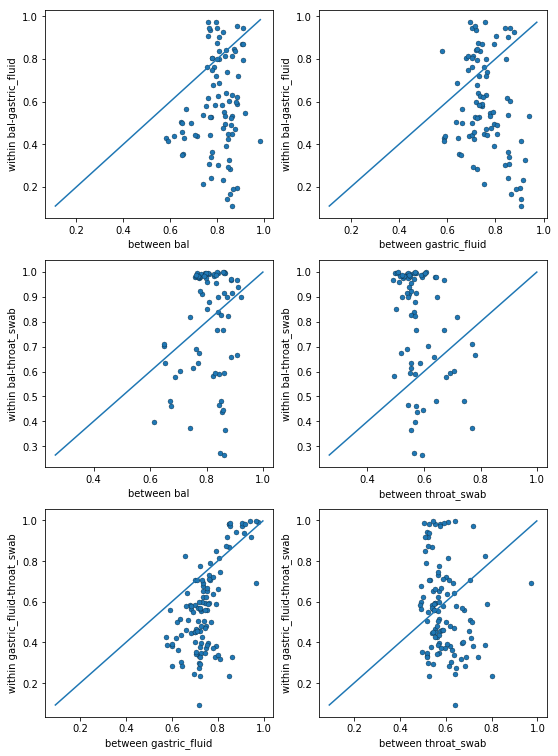

```python
# Scatter plot version!
fig, ax = plt.subplots(3, 2, figsize=(9,13))
ax = ax.flatten()

i = 0
for site_comp, subdf in df.groupby('site_comparison'):
    for site, site_subdf in subdf.groupby('site'):
        # These are the two sets of y-values, paired
        beta_within = site_subdf['within_beta'].values
        beta_between = site_subdf['mean_inter_beta'].values

        ax[i].scatter(beta_between, beta_within,
                   s=25, linewidths=0.25, edgecolor='k')

        min_val = min(np.min(beta_within), np.min(beta_between))
        max_val = max(np.max(beta_within), np.max(beta_between))
        ax[i].plot([min_val, max_val], [min_val, max_val])

        ax[i].set_ylabel('within ' + site_comp)
        ax[i].set_xlabel('between ' + site)

        i += 1
```